# Convert Polar Stereo Coordinates to Lat-Lon

g. Cutter and D. Kinzey

11/8/2020

> notebook filename | reproject_epsg3412_to_4326.Rmd  
> history | Nov 2020: Converted to Rmd notebook, added ERRDAP coordinate retrieval, J. Sevadjian. Feb 2020: Created code snippet, simplified from: AMLR_GIS_in_R by RG. Cutter and D. Kinzey. Nov 2017: AMLR_GIS_in_R.R, G Cutter.

This R code demonstrates converting projected coordinates to latitude longitude coordinates. We will access a dataset with coordinates xgrid, ygrid of NSIDC Sea Ice Polar Stereographic South (EPSG: 3412) from the PolarWatch ERDDAP server and convert the coordinates to WGS84 lat, lon (EPSG:4326).

## Install required packages and load libraries

The required packages are **maptools**, **rgdal**, and **sp**.

```r
# Function to check if pkgs are installed, install missing pkgs, and load
pkgTest <- function(x)
{
  if (!require(x,character.only = TRUE))
  {
    install.packages(x,dep=TRUE,repos='http://cran.us.r-project.org')
    if(!require(x,character.only = TRUE)) stop(x, " :Package not found")
  }
}

list.of.packages <- c("maptools","rgdal","sp", "mapdata", "ggplot2")

# create list of installed packages
pkges = installed.packages()[,"Package"]
for (pk in list.of.packages) {
  pkgTest(pk)
}
```

## Get a list of polar stereo coordinates to work with

- Request and download the coordinate variables from ERDDAP
- The dataset we will use is the NOAA Sea Ice Concentration CDR from NSIDC
- This is a gridded dataset that covers the area around Antarctica
- The request url was generated using the dataset data access form online at https://polarwatch.noaa.gov/erddap/griddap/nsidcCDRiceSQsh1day.html
- There are many additional file format options with ERDDAP, here we demonstrate working with csv output.

```r
url <- 'https://polarwatch.noaa.gov/erddap/griddap/nsidcCDRiceSQsh1day.csv0?ygrid[(4337500.0):10:(-3937500.0)],xgrid[(-3937500.0):10:(3937500.0)]'

download.file(url, destfile='projected_coordinates_input.csv')
```

## Read in the ice coordinates from the .csv file

- Read in the .csv file from our working directory
- Note that with csv output for a gridded dataset like this, the coordinates are listed as arrays (not a grid)
- We will generate coordinate pairs from the lists using **expand**.
- Create a dataframe of coordinate points

```r
infn = "projected_coordinates_input.csv"

indata = read.csv( infn, header=FALSE)

# Create ygrid and xgrid vectors from the data frame columns and remove any padded NaNs
ygrid <- indata$V1[!is.nan(indata$V1)]
xgrid <- indata$V2[!is.nan(indata$V2)]

# Use expand to create a points data frame of all possible coordinate combinations
points.df <- expand.grid(ygrid,xgrid)
```

## Create Spatial Dataframe

Convert the coordinate points dataframe to a spatial object (spatial dataframe)

```r
dfcoords = cbind(points.df$Var1, points.df$Var2)      # coords in y,x order
sppoints = SpatialPoints(coords = dfcoords)
spdf     = SpatialPointsDataFrame(coords = dfcoords, points.df)

# Verify initial coordinates of spatial dataframe
coordsinit <- spdf@coords
```

## Reproject data from EPSG:3412 to EPSG:4326

- Define each of the coordinate reference systems (EPSG:3412 and EPSG:4326)
- Transform the coordinates to Lat Lon with **spTransform**
- Check new coordinates with **coords** and **bbox**

```r
# Define coordinate reference systems
crslatlong       = CRSargs(CRS("+init=epsg:4326"))
crsseaicepolster3412 = CRSargs(CRS("+init=epsg:3412"))

# Set CRS of spatial dataframe
proj4string(spdf) = CRS(crsseaicepolster3412)
ps_bbox       = spdf@bbox
print(ps_bbox)
```

```
##                min     max
## coords.x1 -3912500 4337500
## coords.x2 -3937500 3812500
```

```r
# Check the initial CRS
crs_set = proj4string(spdf)

# Converts from existing crs to latlon (4326)
spdfProjected = spTransform(spdf, CRS(crslatlong))
crs_projected = proj4string(spdfProjected)

coordsproj = spdfProjected@coords
bbox       = spdfProjected@bbox
print( bbox )
```

```
##                  min       max
## coords.x1 -177.63675 178.72697
## coords.x2  -89.00741 -39.36487
```

##Make a map of the data * Map lat/lon coordinate Locations with ggplot

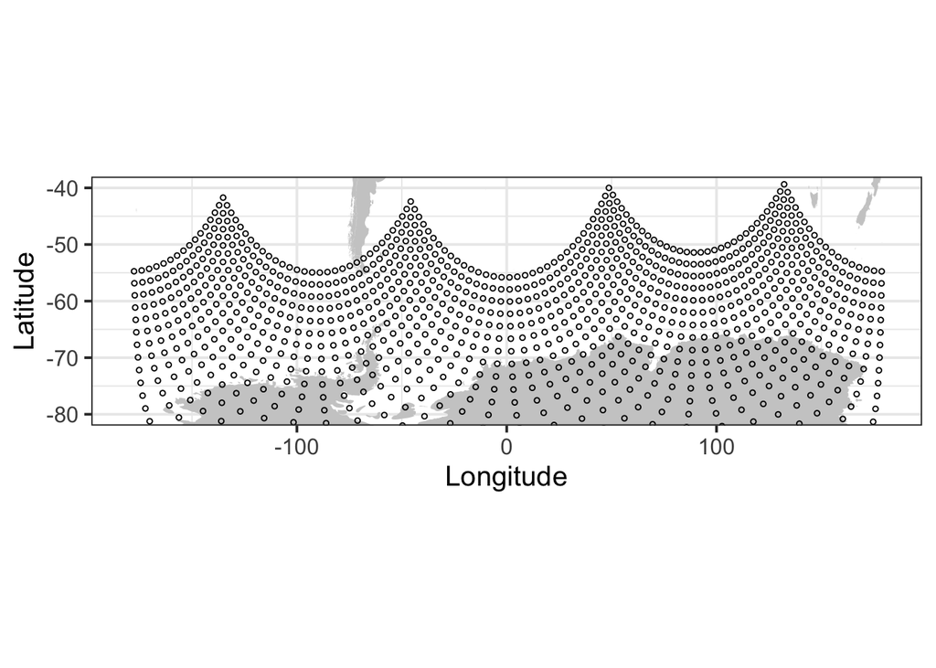

```r
df_latlon <- as.data.frame(spdfProjected)
longitude = df_latlon$coords.x1
xlim <- c(-180,180)
ylim <- c(-80,-40)
coast <- map_data("worldHires", ylim = ylim, xlim = xlim)
main="Argo Float locations, lat/lon coordinates with ggplot"

myplot<-ggplot(data=df_latlon, aes(x=coords.x1,y=coords.x2)) +
  geom_polygon(data = coast, aes(x=long, y = lat, group = group), fill = "grey80") +
  theme_bw(base_size = 15) + ylab("Latitude") + xlab("Longitude") +
  coord_fixed(2.7,xlim = xlim, ylim = ylim) +
  geom_point(data=df_latlon, aes(x=coords.x1,y=coords.x2),inherit.aes = FALSE, size=1,shape=21,color="black")

myplot
```